# Count Regression

2018-02-20

# Poisson regression

$$Y \sim Poisson(\mu)$$

$$P(Y = y) = \frac{e^{-\mu} \mu^{-y}}{y!}$$

Binomial or logistic case but where $p \approx 0$ (but we have a large number of trials per observation to compensate, i.e. $n \rightarrow \infty$).

$y \in \mathbb{N}_0$, no restriction or maximum value on $y$

Note that $E[Y] = var(Y) = \mu$

$Y$ approaches normal distribution as $\mu \rightarrow \infty$

When $p$ is small, $\log \frac{p}{1-p} = \log p - \log (1-p)$ and $\log (1 - p) \approx \log 1 = 0$. Then we are left with $\log p$.

Poisson regression can be appropriate when we do not know the nummber of trials (which means binomial regression is not possible) but we do know the frequency of occurrence.

$$\eta_i = x_i^T \beta$$

Which is the same as before. However, now the link function is

$$\log \mu_i = \eta_i$$

In other words

$$\mu_i = e^{x_i^T \beta}$$

### R demo

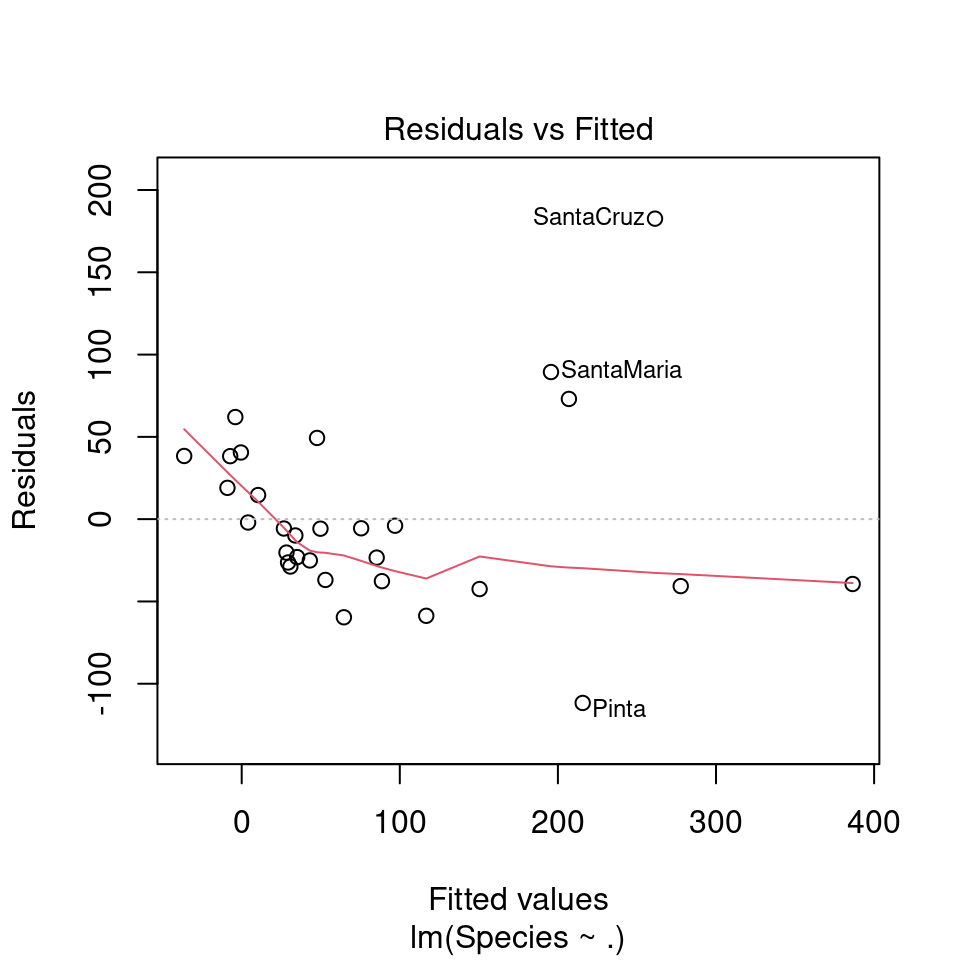

```r
library(faraway)

# Interested in all variables but Endemics (2nd variable)
gala <- gala[, -2]


modl <- lm(Species ~ ., gala)
plot(modl, 1)
```

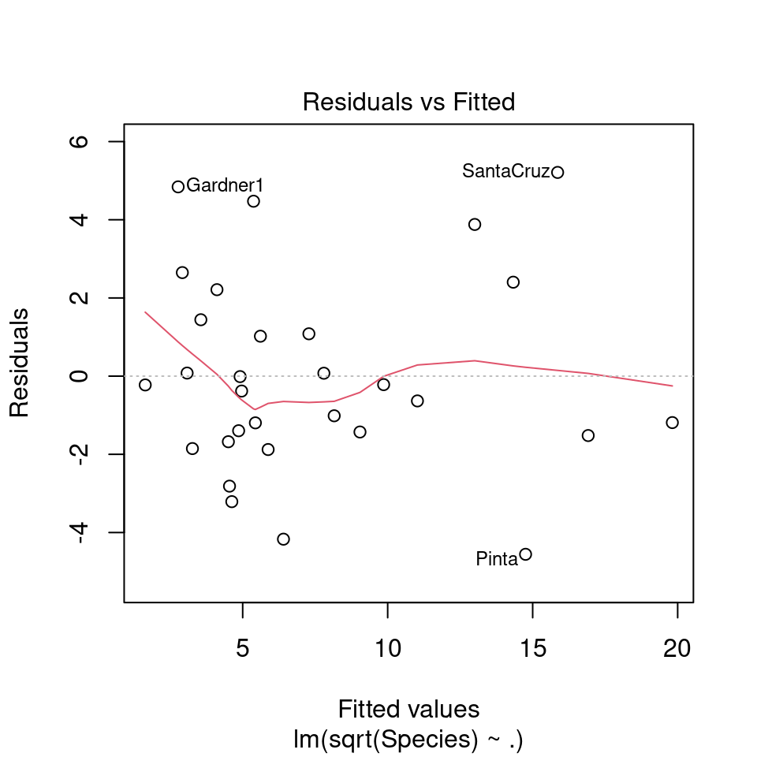

```r
modt <- lm(sqrt(Species) ~ .,  gala)
plot(modt, 1)
```

```r
summary(modt)
```

```
Call:
lm(formula = sqrt(Species) ~ ., data = gala)

Residuals:
    Min      1Q  Median      3Q     Max
-4.5572 -1.4969 -0.3031  1.3527  5.2110

Coefficients:
              Estimate Std. Error t value Pr(>|t|)
(Intercept)  3.3919243  0.8712678   3.893 0.000690 ***
Area        -0.0019718  0.0010199  -1.933 0.065080 .
Elevation    0.0164784  0.0024410   6.751 5.55e-07 ***
Nearest      0.0249326  0.0479495   0.520 0.607844
Scruz       -0.0134826  0.0097980  -1.376 0.181509
Adjacent    -0.0033669  0.0008051  -4.182 0.000333 ***
---
Signif. codes:  0 '***' 0.001 '**' 0.01 '*' 0.05 '.' 0.1 ' ' 1

Residual standard error: 2.774 on 24 degrees of freedom
Multiple R-squared:  0.7827,    Adjusted R-squared:  0.7374
F-statistic: 17.29 on 5 and 24 DF,  p-value: 2.874e-07
```

```r
modp = glm(Species ~ ., family=poisson, gala)
summary(modp)
```

```
Call:
glm(formula = Species ~ ., family = poisson, data = gala)

Deviance Residuals:
    Min       1Q   Median       3Q      Max
-8.2752  -4.4966  -0.9443   1.9168  10.1849

Coefficients:
              Estimate Std. Error z value Pr(>|z|)
(Intercept)  3.155e+00  5.175e-02  60.963  < 2e-16 ***
Area        -5.799e-04  2.627e-05 -22.074  < 2e-16 ***
Elevation    3.541e-03  8.741e-05  40.507  < 2e-16 ***
Nearest      8.826e-03  1.821e-03   4.846 1.26e-06 ***
Scruz       -5.709e-03  6.256e-04  -9.126  < 2e-16 ***
Adjacent    -6.630e-04  2.933e-05 -22.608  < 2e-16 ***
---
Signif. codes:  0 '***' 0.001 '**' 0.01 '*' 0.05 '.' 0.1 ' ' 1

(Dispersion parameter for poisson family taken to be 1)

    Null deviance: 3510.73  on 29  degrees of freedom
Residual deviance:  716.85  on 24  degrees of freedom
AIC: 889.68

Number of Fisher Scoring iterations: 5
```

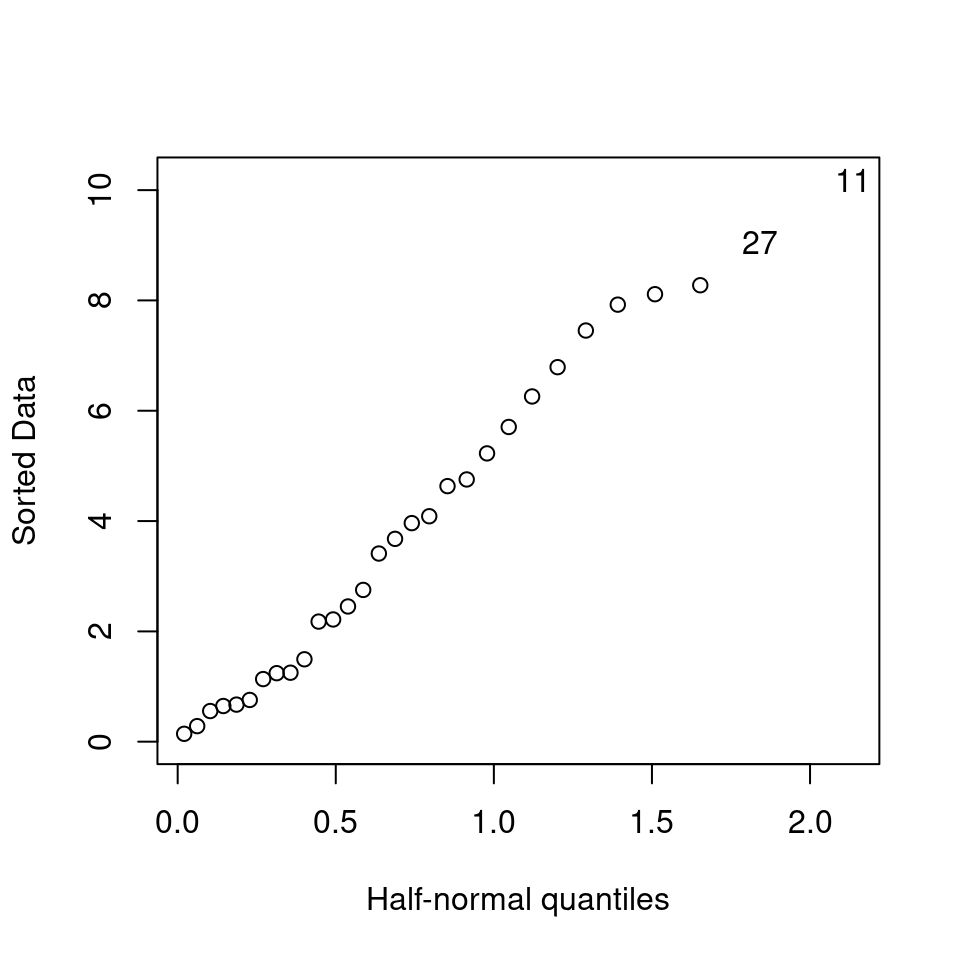

```r
halfnorm(residuals(modp))
```

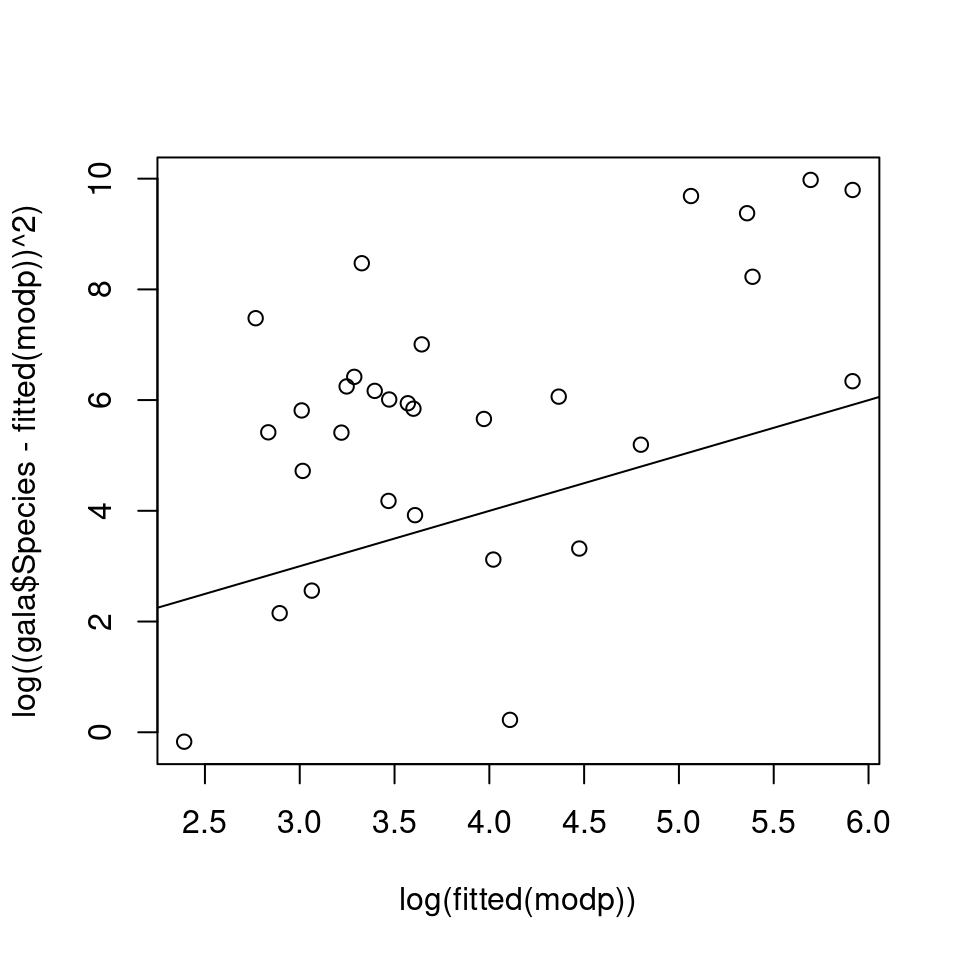

```r
plot(log(fitted(modp)), log((gala$Species - fitted(modp))^2))
abline(0, 1)
```

```r
# dispersion parameter
dp <- sum(residuals(modp, type = 'pearson') ** 2) / modp$df.res
summary(modp, dispersion = dp)
```

```
Call:
glm(formula = Species ~ ., family = poisson, data = gala)

Deviance Residuals:
    Min       1Q   Median       3Q      Max
-8.2752  -4.4966  -0.9443   1.9168  10.1849

Coefficients:
              Estimate Std. Error z value Pr(>|z|)
(Intercept)  3.1548079  0.2915897  10.819  < 2e-16 ***
Area        -0.0005799  0.0001480  -3.918 8.95e-05 ***
Elevation    0.0035406  0.0004925   7.189 6.53e-13 ***
Nearest      0.0088256  0.0102621   0.860    0.390
Scruz       -0.0057094  0.0035251  -1.620    0.105
Adjacent    -0.0006630  0.0001653  -4.012 6.01e-05 ***
---
Signif. codes:  0 '***' 0.001 '**' 0.01 '*' 0.05 '.' 0.1 ' ' 1

(Dispersion parameter for poisson family taken to be 31.74914)

    Null deviance: 3510.73  on 29  degrees of freedom
Residual deviance:  716.85  on 24  degrees of freedom
AIC: 889.68

Number of Fisher Scoring iterations: 5
```

```r
modd <- glm(Species ~ ., family = quasipoisson, data = gala)
summary(modd)
```

```
Call:
glm(formula = Species ~ ., family = quasipoisson, data = gala)

Deviance Residuals:
    Min       1Q   Median       3Q      Max
-8.2752  -4.4966  -0.9443   1.9168  10.1849

Coefficients:
              Estimate Std. Error t value Pr(>|t|)
(Intercept)  3.1548079  0.2915901  10.819 1.03e-10 ***
Area        -0.0005799  0.0001480  -3.918 0.000649 ***
Elevation    0.0035406  0.0004925   7.189 1.98e-07 ***
Nearest      0.0088256  0.0102622   0.860 0.398292
Scruz       -0.0057094  0.0035251  -1.620 0.118380
Adjacent    -0.0006630  0.0001653  -4.012 0.000511 ***
---
Signif. codes:  0 '***' 0.001 '**' 0.01 '*' 0.05 '.' 0.1 ' ' 1

(Dispersion parameter for quasipoisson family taken to be 31.74921)

    Null deviance: 3510.73  on 29  degrees of freedom
Residual deviance:  716.85  on 24  degrees of freedom
AIC: NA

Number of Fisher Scoring iterations: 5
```

```r
drop1(modd, test = 'F')
```

```
Single term deletions

Model:
Species ~ Area + Elevation + Nearest + Scruz + Adjacent
          Df Deviance F value    Pr(>F)
<none>         716.85
Area       1  1204.35 16.3217 0.0004762 ***
Elevation  1  2389.57 56.0028 1.007e-07 ***
Nearest    1   739.41  0.7555 0.3933572
Scruz      1   813.62  3.2400 0.0844448 .
Adjacent   1  1341.45 20.9119 0.0001230 ***
---
Signif. codes:  0 '***' 0.001 '**' 0.01 '*' 0.05 '.' 0.1 ' ' 1
```

# Rate models

Consider two models:

- OLS model (possibly with transformations and interaction terms) $E[y|X] = X \beta$; in this example $y$ is the log of the response and we have two regressors, the log of a continuous predictor and a categorical predictor, along with interaction terms. Then $y_i \sim \mathcal{N}(x_i^T \beta, \sigma^2 I)$. This makes an assumption on the distribution of $y_i$s. Once we have a lot of transformations and interactions, we start losing interpretability.
- $y \sim Poisson(\mu)$ where $y$ is an untransformed response. Since we do not transform the response, this should be easier to interpret. Here we are essentially saying that $\log(y|X)$ is linear, where again, $y$ is untransformed. But $y$ needs to be some sort of rate. We can enforce this by setting $y$ to a count and including an offset for the total in the model. In practice, you may need to check this in the data.

```r
library(faraway)

summary(dicentric)
```

```
     cells              ca           doseamt         doserate
 Min.   :  90.0   Min.   : 25.0   Min.   :1.000   Min.   :0.10
 1st Qu.: 183.5   1st Qu.:100.0   1st Qu.:1.000   1st Qu.:0.50
 Median : 298.0   Median :106.0   Median :2.500   Median :1.50
 Mean   : 640.7   Mean   :120.4   Mean   :2.833   Mean   :1.65
 3rd Qu.:1001.0   3rd Qu.:122.5   3rd Qu.:5.000   3rd Qu.:2.50
 Max.   :2329.0   Max.   :419.0   Max.   :5.000   Max.   :4.00
```

```r
dicentric$doseamt <- as.factor(dicentric$doseamt)

ols.mod <- lm(log(ca / cells) ~ log(doserate) * doseamt, data = dicentric)
summary(ols.mod)
```

```
Call:
lm(formula = log(ca/cells) ~ log(doserate) * doseamt, data = dicentric)

Residuals:
     Min       1Q   Median       3Q      Max
-0.16950 -0.05413  0.00585  0.06717  0.16343

Coefficients:
                         Estimate Std. Error t value Pr(>|t|)
(Intercept)              -2.76243    0.03352 -82.402  < 2e-16 ***
log(doserate)             0.07561    0.02866   2.638 0.015364 *
doseamt2.5                1.64378    0.04741  34.672  < 2e-16 ***
doseamt5                  2.77866    0.04741  58.610  < 2e-16 ***
log(doserate):doseamt2.5  0.16483    0.04053   4.067 0.000553 ***
log(doserate):doseamt5    0.19480    0.04053   4.807 9.47e-05 ***
---
Signif. codes:  0 '***' 0.001 '**' 0.01 '*' 0.05 '.' 0.1 ' ' 1

Residual standard error: 0.1006 on 21 degrees of freedom
Multiple R-squared:  0.9943,    Adjusted R-squared:  0.9929
F-statistic: 729.4 on 5 and 21 DF,  p-value: < 2.2e-16
```

```r
pois.mod <- glm(ca ~ offset(log(cells)) + log(doserate) * doseamt,
                family = poisson, data = dicentric)
summary(pois.mod)
```

```
Call:
glm(formula = ca ~ offset(log(cells)) + log(doserate) * doseamt,
    family = poisson, data = dicentric)

Deviance Residuals:
     Min        1Q    Median        3Q       Max
-1.49101  -0.62473  -0.05078   0.76786   1.59115

Coefficients:
                         Estimate Std. Error z value Pr(>|z|)
(Intercept)              -2.74671    0.03426 -80.165  < 2e-16 ***
log(doserate)             0.07178    0.03518   2.041 0.041299 *
doseamt2.5                1.62542    0.04946  32.863  < 2e-16 ***
doseamt5                  2.76109    0.04349  63.491  < 2e-16 ***
log(doserate):doseamt2.5  0.16122    0.04830   3.338 0.000844 ***
log(doserate):doseamt5    0.19350    0.04243   4.561  5.1e-06 ***
---
Signif. codes:  0 '***' 0.001 '**' 0.01 '*' 0.05 '.' 0.1 ' ' 1

(Dispersion parameter for poisson family taken to be 1)

    Null deviance: 4753.00  on 26  degrees of freedom
Residual deviance:   21.75  on 21  degrees of freedom
AIC: 209.16

Number of Fisher Scoring iterations: 4
```

# Negative binomial

If we determine the Poisson model is not appropriate (e.g., due to overdisperson)—need to increase dispersion

$\theta$ parameter—corresponds to $\hat{k}$ parameter in text

```r
library(MASS)

summary(solder)
```

```
 Opening   Solder      Mask        PadType        Panel       skips
 L:300   Thick:450   A1.5:180   D4     : 90   Min.   :1   Min.   : 0.00
 M:300   Thin :450   A3  :270   D6     : 90   1st Qu.:1   1st Qu.: 0.00
 S:300               A6  : 90   D7     : 90   Median :2   Median : 2.00
                     B3  :180   L4     : 90   Mean   :2   Mean   : 5.53
                     B6  :180   L6     : 90   3rd Qu.:3   3rd Qu.: 7.00
                                L7     : 90   Max.   :3   Max.   :48.00
                                (Other):360
```

```r
pois.mod <- glm(skips ~ ., data = solder, family = poisson)
summary(pois.mod)
```

```
Call:
glm(formula = skips ~ ., family = poisson, data = solder)

Deviance Residuals:
    Min       1Q   Median       3Q      Max
-3.6413  -1.2562  -0.5286   0.5670   4.7289

Coefficients:
            Estimate Std. Error z value Pr(>|z|)
(Intercept) -1.10042    0.09267 -11.874  < 2e-16 ***
OpeningM     0.57161    0.05707  10.017  < 2e-16 ***
OpeningS     1.81475    0.05044  35.980  < 2e-16 ***
SolderThin   0.84682    0.03327  25.453  < 2e-16 ***
MaskA3       0.51315    0.07098   7.230 4.83e-13 ***
MaskA6       1.81103    0.06609  27.404  < 2e-16 ***
MaskB3       1.20225    0.06697  17.953  < 2e-16 ***
MaskB6       1.86648    0.06310  29.580  < 2e-16 ***
PadTypeD6   -0.40328    0.06028  -6.690 2.24e-11 ***
PadTypeD7   -0.08979    0.05521  -1.626 0.103852
PadTypeL4    0.22460    0.05117   4.389 1.14e-05 ***
PadTypeL6   -0.70633    0.06637 -10.642  < 2e-16 ***
PadTypeL7   -0.48260    0.06176  -7.814 5.52e-15 ***
PadTypeL8   -0.30778    0.05862  -5.251 1.51e-07 ***
PadTypeL9   -0.63793    0.06489  -9.831  < 2e-16 ***
PadTypeW4   -0.19021    0.05671  -3.354 0.000796 ***
PadTypeW9   -1.56252    0.09165 -17.048  < 2e-16 ***
Panel        0.14670    0.01745   8.405  < 2e-16 ***
---
Signif. codes:  0 '***' 0.001 '**' 0.01 '*' 0.05 '.' 0.1 ' ' 1

(Dispersion parameter for poisson family taken to be 1)

    Null deviance: 8788.2  on 899  degrees of freedom
Residual deviance: 1829.0  on 882  degrees of freedom
AIC: 3967.6

Number of Fisher Scoring iterations: 5
```

```r
neg.binom.mod <- glm.nb(skips ~ ., data = solder)
summary(neg.binom.mod)
```

```
Call:
glm.nb(formula = skips ~ ., data = solder, init.theta = 4.397157245,
    link = log)

Deviance Residuals:
    Min       1Q   Median       3Q      Max
-2.7376  -1.0068  -0.3834   0.4460   2.7829

Coefficients:
            Estimate Std. Error z value Pr(>|z|)
(Intercept) -1.42245    0.14274  -9.965  < 2e-16 ***
OpeningM     0.50294    0.07976   6.306 2.87e-10 ***
OpeningS     1.91317    0.07152  26.750  < 2e-16 ***
SolderThin   0.93932    0.05362  17.517  < 2e-16 ***
MaskA3       0.58981    0.09651   6.112 9.87e-10 ***
MaskA6       2.26734    0.10182  22.269  < 2e-16 ***
MaskB3       1.21101    0.09637  12.566  < 2e-16 ***
MaskB6       1.99037    0.09223  21.580  < 2e-16 ***
PadTypeD6   -0.46592    0.11238  -4.146 3.38e-05 ***
PadTypeD7   -0.03315    0.10673  -0.311 0.756114
PadTypeL4    0.38268    0.10265   3.728 0.000193 ***
PadTypeL6   -0.57844    0.11413  -5.068 4.01e-07 ***
PadTypeL7   -0.36656    0.11094  -3.304 0.000953 ***
PadTypeL8   -0.15890    0.10821  -1.468 0.141986
PadTypeL9   -0.56600    0.11393  -4.968 6.77e-07 ***
PadTypeW4   -0.20044    0.10873  -1.844 0.065255 .
PadTypeW9   -1.56460    0.13621 -11.486  < 2e-16 ***
Panel        0.16369    0.03139   5.214 1.85e-07 ***
---
Signif. codes:  0 '***' 0.001 '**' 0.01 '*' 0.05 '.' 0.1 ' ' 1

(Dispersion parameter for Negative Binomial(4.3972) family taken to be 1)

    Null deviance: 4043.3  on 899  degrees of freedom
Residual deviance: 1008.3  on 882  degrees of freedom
AIC: 3683.3

Number of Fisher Scoring iterations: 1

              Theta:  4.397
          Std. Err.:  0.495

 2 x log-likelihood:  -3645.309
```

# Zero-inflated models

Use when there are too many zeroes for a Poisson model (the number of *zeroes* is *inflated*)

## Hurdle

$P(Y = 0) = f_1(0)$  
$P(Y = j) = \frac{1 - f_1(0)}{1 - f_2(0)} f_2(j)$

Basically some distribution for whether something happens or not, then another distribution for how much of it happens once it does happen (so once it crosses a “hurdle”)

We model:

- $f_1$ as a binary response (with logit link function)
- $f_2$ as Poisson

Motivation behind the ratio $\frac{1 - f_1(0)}{1 - f_2(0)}$:

$\sum_{j=0}^\infty P(Y = j) = 1$  
Then $f_1(0) + \sum_{j=1}^\infty P(Y = j) = 1$  
Then $f_1(0) + \sum_{j=1}^\infty \frac{1 - f_1(0)}{1 - f_2(0)} = 1$

```r
library(pscl)

m1 <- glm(art ~ ., data = bioChemists, family = poisson)
summary(m1)
```

```
Call:
glm(formula = art ~ ., family = poisson, data = bioChemists)

Deviance Residuals:
    Min       1Q   Median       3Q      Max
-3.5672  -1.5398  -0.3660   0.5722   5.4467

Coefficients:
             Estimate Std. Error z value Pr(>|z|)
(Intercept)  0.304617   0.102981   2.958   0.0031 **
femWomen    -0.224594   0.054613  -4.112 3.92e-05 ***
marMarried   0.155243   0.061374   2.529   0.0114 *
kid5        -0.184883   0.040127  -4.607 4.08e-06 ***
phd          0.012823   0.026397   0.486   0.6271
ment         0.025543   0.002006  12.733  < 2e-16 ***
---
Signif. codes:  0 '***' 0.001 '**' 0.01 '*' 0.05 '.' 0.1 ' ' 1

(Dispersion parameter for poisson family taken to be 1)

    Null deviance: 1817.4  on 914  degrees of freedom
Residual deviance: 1634.4  on 909  degrees of freedom
AIC: 3314.1

Number of Fisher Scoring iterations: 5
```

```r
m2 <- hurdle(art ~ ., data = bioChemists)
summary(m2)
```

```
Call:
hurdle(formula = art ~ ., data = bioChemists)

Pearson residuals:
    Min      1Q  Median      3Q     Max
-2.4105 -0.8913 -0.2817  0.5530  7.0324

Count model coefficients (truncated poisson with log link):
            Estimate Std. Error z value Pr(>|z|)
(Intercept)  0.67114    0.12246   5.481 4.24e-08 ***
femWomen    -0.22858    0.06522  -3.505 0.000457 ***
marMarried   0.09649    0.07283   1.325 0.185209
kid5        -0.14219    0.04845  -2.934 0.003341 **
phd         -0.01273    0.03130  -0.407 0.684343
ment         0.01875    0.00228   8.222  < 2e-16 ***
Zero hurdle model coefficients (binomial with logit link):
            Estimate Std. Error z value Pr(>|z|)
(Intercept)  0.23680    0.29552   0.801   0.4230
femWomen    -0.25115    0.15911  -1.579   0.1144
marMarried   0.32623    0.18082   1.804   0.0712 .
kid5        -0.28525    0.11113  -2.567   0.0103 *
phd          0.02222    0.07956   0.279   0.7800
ment         0.08012    0.01302   6.155 7.52e-10 ***
---
Signif. codes:  0 '***' 0.001 '**' 0.01 '*' 0.05 '.' 0.1 ' ' 1

Number of iterations in BFGS optimization: 12
Log-likelihood: -1605 on 12 Df
```

## Zero Inflation

$P(Y = 0) = \phi + (1 - \phi) f(0)$  
$P(Y = j) = (1 - \phi) f(j)$ for $j > 0$

Where $\phi$ is the proportion that will always be zero

$f$ is the pmf for $Poisson(\mu)$

```r
m3 <- zeroinfl(art ~ ., data = bioChemists)
summary(m3)
```

```
Call:
zeroinfl(formula = art ~ ., data = bioChemists)

Pearson residuals:
    Min      1Q  Median      3Q     Max
-2.3253 -0.8652 -0.2826  0.5404  7.2976

Count model coefficients (poisson with log link):
             Estimate Std. Error z value Pr(>|z|)
(Intercept)  0.640839   0.121307   5.283 1.27e-07 ***
femWomen    -0.209144   0.063405  -3.299 0.000972 ***
marMarried   0.103750   0.071111   1.459 0.144567
kid5        -0.143320   0.047429  -3.022 0.002513 **
phd         -0.006166   0.031008  -0.199 0.842376
ment         0.018098   0.002294   7.888 3.07e-15 ***

Zero-inflation model coefficients (binomial with logit link):
             Estimate Std. Error z value Pr(>|z|)
(Intercept) -0.577060   0.509386  -1.133  0.25728
femWomen     0.109752   0.280082   0.392  0.69517
marMarried  -0.354018   0.317611  -1.115  0.26501
kid5         0.217095   0.196483   1.105  0.26920
phd          0.001275   0.145263   0.009  0.99300
ment        -0.134114   0.045243  -2.964  0.00303 **
---
Signif. codes:  0 '***' 0.001 '**' 0.01 '*' 0.05 '.' 0.1 ' ' 1

Number of iterations in BFGS optimization: 19
Log-likelihood: -1605 on 12 Df
```

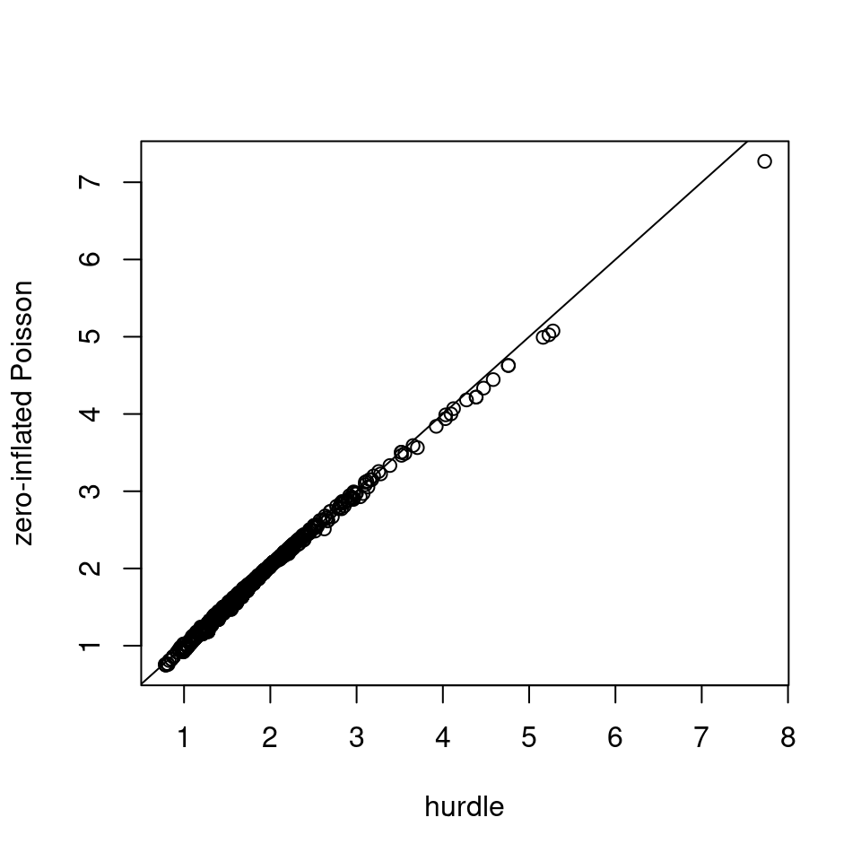

```r
plot(fitted(m2), fitted(m3), xlab = 'hurdle', ylab = 'zero-inflated Poisson')
abline(0, 1)
```

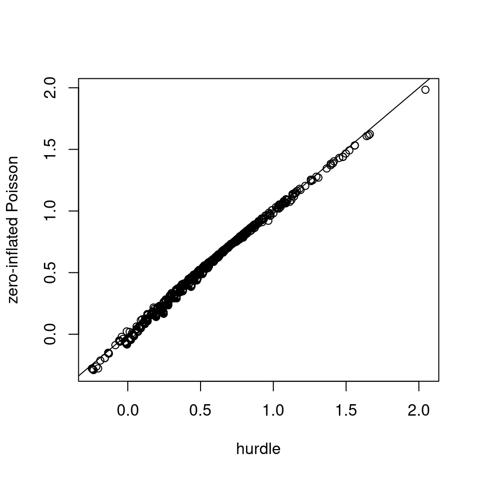

```r
plot(log(fitted(m2)), log(fitted(m3)),
     xlab = 'hurdle', ylab = 'zero-inflated Poisson')
abline(0, 1)
```

```r
m4 <- zeroinfl(art ~ fem + kid5 + ment | ment, data = bioChemists)
summary(m4)
```

```
Call:
zeroinfl(formula = art ~ fem + kid5 + ment | ment, data = bioChemists)

Pearson residuals:
    Min      1Q  Median      3Q     Max
-2.2802 -0.8807 -0.2718  0.5131  7.4788

Count model coefficients (poisson with log link):
             Estimate Std. Error z value Pr(>|z|)
(Intercept)  0.694517   0.053025  13.098  < 2e-16 ***
femWomen    -0.233857   0.058400  -4.004 6.22e-05 ***
kid5        -0.126516   0.039668  -3.189  0.00143 **
ment         0.018004   0.002224   8.096 5.67e-16 ***

Zero-inflation model coefficients (binomial with logit link):
            Estimate Std. Error z value Pr(>|z|)
(Intercept) -0.68488    0.20529  -3.336 0.000849 ***
ment        -0.12680    0.03981  -3.185 0.001448 **
---
Signif. codes:  0 '***' 0.001 '**' 0.01 '*' 0.05 '.' 0.1 ' ' 1

Number of iterations in BFGS optimization: 22
Log-likelihood: -1608 on 6 Df
```

```r
pchisq(2 * (m3$loglik - m4$loglik), 6, lower.tail = FALSE)
```

```
[1] 0.4041153
```

```r
exp(coef(m4))
```

```
count_(Intercept)    count_femWomen        count_kid5        count_ment
        2.0027411         0.7914748         0.8811604         1.0181669
 zero_(Intercept)         zero_ment
        0.5041522         0.8809081
```

```r
predict(m3,
        newdata = data.frame(fem = 'Men', mar = 'Single',
                             kid5 = 0, ment = 6, phd = 0),
        type = 'prob')
```

```
          0         1         2        3          4          5          6
1 0.2970719 0.2038413 0.2156421 0.152084 0.08044423 0.03404052 0.01200373
            7            8            9           10           11         12
1 0.003628185 0.0009595569 0.0002255794 4.772773e-05 9.180141e-06 1.6186e-06
            13           14           15           16           17           18
1 2.634313e-07 3.981169e-08 5.615528e-09 7.425777e-10 9.241964e-11 1.086333e-11
            19
1 1.209708e-12
```

### Interpretation

In `m4`, we get:

- If you are already writing a paper, then $\hat{\mu} = e^{X \hat{\beta}}$ where the $\hat{\beta}$ come from the Poisson model. Then for each additional paper from the mentor, on average the expected number of publications increases by 1.8%.
- The probability that you have not published anything decreases by $1 - .881$. So for each additional paper your mentor produces, the odds of not having published reduces by around 12%.

# Considerations for the exam

- Transformations?
- Can disregard negative binomial models